# ProjectV_Poblet

Marcel Poblet

November 8, 2016

## Tooth Growth

The data set we are using displays the length of odontoblasts(tooth growth cells) in guinea pigs receiving three different doses of vitamin C in the form of orange juice (OJ) or ascorbic acid (VC).

### Growth by Supplement

This plot displays the rate of growth through Orange Juice(OJ) and Ascorbic Acid(VC).

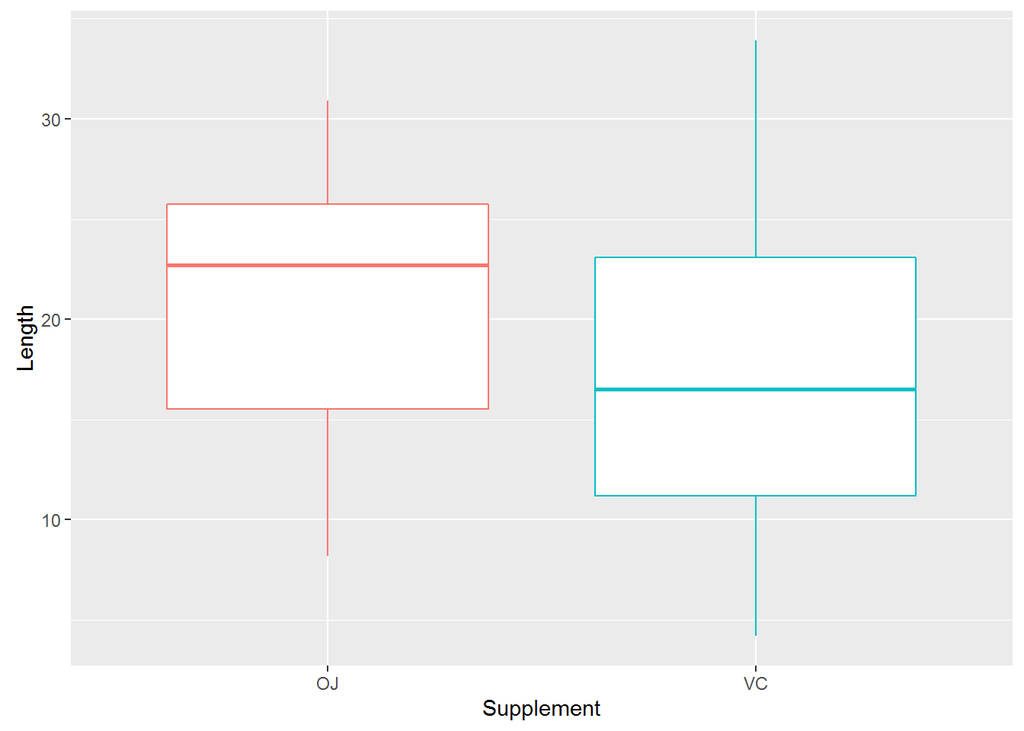

### Growth by Dose

This plot displays the rate of growth by dose.

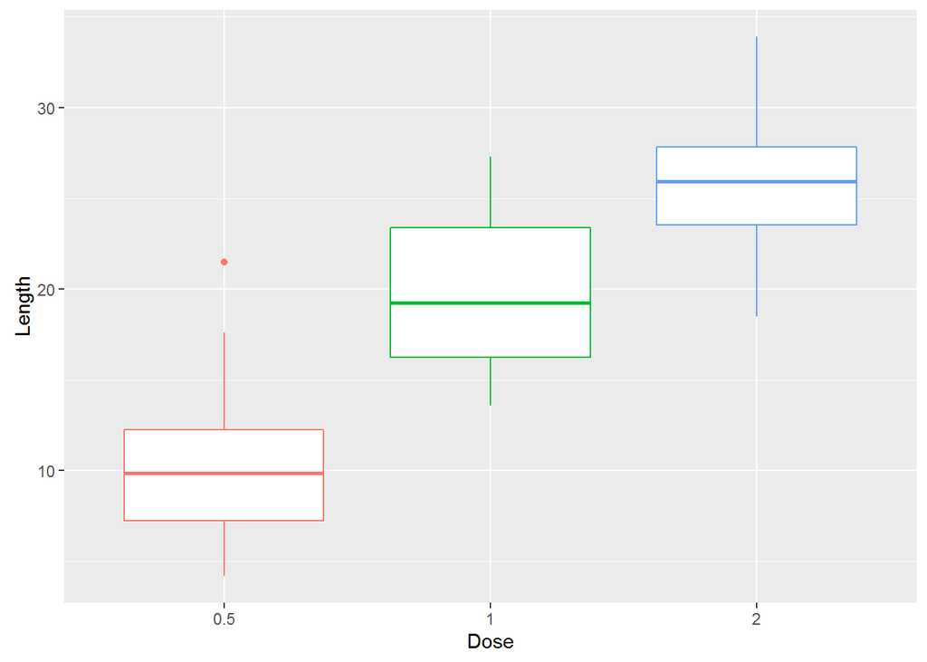

### Growth by Supplement and Dose

This plot displays the rate of growth by dose for each supplement Orange Juice(OJ) and Ascorbic Acid(VC).

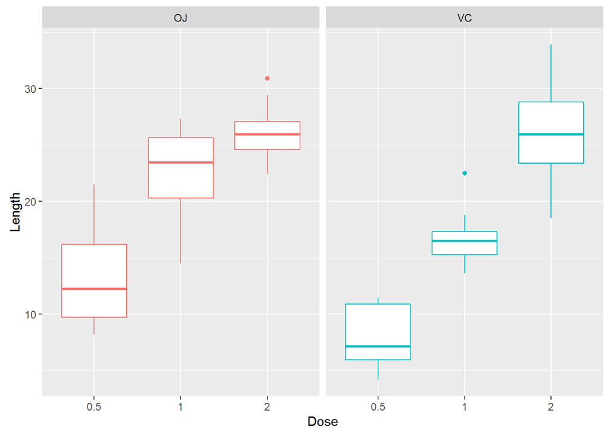

It appears that as the dosage increases, so does the length of the guinea pigs’ teeth. It’s also evident that larger doses of ascorbic acid have a wider range of effect than the smaller doses.The reverse seems true for orange juice, where the smaller doses have a wider range than the larger doses.

## Confidence Intervals

Let’s separate the data into two separate fields. One for all the guinea pigs who recieved vitamin C through orange juice (guineaOJ) and one for those who received vitamin C through ascorbic acid (guineaVC).

```r
guineaOJ <- filter(ToothGrowth, supp == "OJ")
guineaVC <- filter(ToothGrowth, supp == "VC")
```

### Guinea Pigs on Ascorbic Acid

We are going to construct a 95% confidence interval for mean amount of growth one could expect for guinea pigs receiving the supplement ascorbic acid in any dosage.

```r
guineaConfVC <- t.test(guineaVC$len)
confFormat(guineaConfVC)
```

```
##       Min      Max
##  13.87675 20.04992
```

As shown above the 95% confidence interval lies between 13.8767 and 20.0499 for guinea pigs taking any dosage of ascorbic acid.

### Guinea Pigs On 2mg Dosage of Orange Juice

Next let’s run the same test on guinea pigs taking 2mg of orange juice.

```r
guineaTwoOJ <- filter(guineaOJ, as.factor(dose) == 2)
guineaConfOJ <- t.test(guineaTwoOJ$len)
confFormat(guineaConfOJ)
```

```
##       Min      Max
##  24.16069 27.95931
```

Guinea pigs receiving only 2mg of orange juice had a 95 percent confidence interval between 24.1607 and 27.9593.

## Hypothesis Testing

### Orange Juice vs. Ascorbic Acid

We’ll start with testing the difference between the growth of guinea pigs’ teeth taking orange juice versus those taking ascorbic acid. $H_0 : \mu _{OJ} = \mu _{VC}$ versus $H_a : \mu _{OJ} \ne \mu _{VC}$

```r
guineaVersus <- t.test(guineaOJ$len, guineaVC$len)
guineaVersus
```

```
##
##  Welch Two Sample t-test
##
## data:  guineaOJ$len and guineaVC$len
## t = 1.9153, df = 55.309, p-value = 0.06063
## alternative hypothesis: true difference in means is not equal to 0
## 95 percent confidence interval:
##  -0.1710156  7.5710156
## sample estimates:
## mean of x mean of y
##  20.66333  16.96333
```

The results of our t-test gives us a t-value of 1.9153 and a p-value of 0.0606. This shows that there is not a significance in our standard significance level of .05 and we fail to reject the null hypothesis. We compared the difference in guinea pigs’ tooth growth when taking vitamin C in the form of orange juice and ascorbic acid and the results don’t show that there is a true difference between them.

### 2mg of OJ vs. 1mg

Let’s take two different dosage levels of orange juice given to the guinea pigs. We will use the 2mg and 1mg dosages.  
$H_0 : \mu _{1mg} = \mu _{2mg}$ versus $H_a : \mu _{1mg} \lt \mu _{2mg}$  
First we filter out the .5mg dose from guineaOJ

```r
guineaOJDose <- filter(guineaOJ, as.factor(dose) != .5)
```

The new data frame inlcudes all doses except .5mg. Now we are ready to conduct our t-test.

```r
guineaOJTest <- t.test(len ~ as.factor(dose), data = guineaOJDose, alternative = "l")
guineaOJTest
```

```
##
##  Welch Two Sample t-test
##
## data:  len by as.factor(dose)
## t = -2.2478, df = 15.842, p-value = 0.0196
## alternative hypothesis: true difference in means is less than 0
## 95 percent confidence interval:
##        -Inf -0.7486236
## sample estimates:
## mean in group 1 mean in group 2
##           22.70           26.06
```

The results show our t-value being -2.2478 and p-value being 0.0196. These results are significant at .05 significance and justify our alternative hypothesis and therefore we reject the null hypothesis. The goal was to prove if taking a larger dose of vitamin C in the form of orange juice would increase the growth of guinea pigs’ teeth and the results suggest that there is a true difference between guinea pigs taking 1mg of orange juice to those taking 2mg.

### 1mg of VC vs. 2mg

We will take two different dosage levels of ascorbic acid given to the guinea pigs. The 2mg and 1mg dosages.  
$H_0 : \mu _{1mg} = \mu _{2mg}$ versus $H_a : \mu _{1mg} \lt \mu _{2mg}$  
First we filter out the .5mg dose from guineaVC

```r
guineaVCDose <- filter(guineaVC, as.factor(dose) != .5)
```

The new data frame inlcudes all doses except .5mg. Now we are ready to conduct our t-test.

```r
guineaVCTest <- t.test(len ~ as.factor(dose), data = guineaVCDose, alternative = "l")
guineaVCTest
```

```
##
##  Welch Two Sample t-test
##
## data:  len by as.factor(dose)
## t = -5.4698, df = 13.6, p-value = 4.578e-05
## alternative hypothesis: true difference in means is less than 0
## 95 percent confidence interval:
##       -Inf -6.346525
## sample estimates:
## mean in group 1 mean in group 2
##           16.77           26.14
```

The results shows our t-value of -5.4698 and p-value of 4.578e-05. These results are significant and we reject the null hypothesis. The goal was to prove if taking a larger dose of vitamin C in the form of acsorbic acid would increase the growth of guinea pigs’ teeth and the results suggest that there is a true difference between guinea pigs taking 1mg of acsorbic acid and those taking 2mg.

### 1mg. of OJ vs. 1mg of VC

Now we are going to compare the two different supplements using the dosage at 1mg.  
$H_0 : \mu _{1mg OJ} = \mu _{1mg VC}$ versus $H_a : \mu _{1mg OJ} \ne \mu _{1mg VC}$  
Let’s create some data frames with just 1mg dosage for each supplement.

```r
guineaOJOne <- filter(guineaOJ, as.factor(dose) == 1)
guineaVCOne <- filter(guineaVC, as.factor(dose) == 1)
```

We can now run a t-test with our data using only 1mg dosages from each supplement.

```r
guineaOneVersus <- t.test(guineaOJOne$len,guineaVCOne$len)
guineaOneVersus
```

```
##
##  Welch Two Sample t-test
##
## data:  guineaOJOne$len and guineaVCOne$len
## t = 4.0328, df = 15.358, p-value = 0.001038
## alternative hypothesis: true difference in means is not equal to 0
## 95 percent confidence interval:
##  2.802148 9.057852
## sample estimates:
## mean of x mean of y
##     22.70     16.77
```

From the results above we can see our t-value is 4.0328 and p-value is 0.0010 and the test shows that our results were significant, therefore we reject the null hypothesis. The comparison was done on 1mg dosages of orange juice to 1mg dosages of ascorbic acid and the results suggest that there is a true difference in the supplements given to the guinea pigs.

### 2mg. of OJ vs. 2mg of VC

We are going to compare the two different supplements using the dosage at 2mg now.  
$H_0 : \mu _{2mg OJ} = \mu _{2mg VC}$ versus $H_a : \mu _{2mg OJ} \ne \mu _{2mg VC}$  
Let’s create our data frames again, this time with 2mg dosages for each supplement.

```r
guineaOJTwo <- filter(guineaOJ, as.factor(dose) == 2)
guineaVCTwo <- filter(guineaVC, as.factor(dose) == 2)
```

Running t-test on our filtered data frames below.

```r
guineaTwoVersus <- t.test(guineaOJTwo$len,guineaVCTwo$len)
guineaTwoVersus
```

```
##
##  Welch Two Sample t-test
##
## data:  guineaOJTwo$len and guineaVCTwo$len
## t = -0.046136, df = 14.04, p-value = 0.9639
## alternative hypothesis: true difference in means is not equal to 0
## 95 percent confidence interval:
##  -3.79807  3.63807
## sample estimates:
## mean of x mean of y
##     26.06     26.14
```

The results above display our t-value as -0.0461 and p-value as 0.9639. The test shows that our results were not significant, and we fail to reject the null hypothesis. We compared the length of guinea pigs’ teeth when taking 2mg of orange juice and those taking 2mg of ascorbic acid and the results don’t suggest that there is a difference between the populations.